# `ggspectra` 0.1.3 User Guide

### Totals by waveband

Our `stat_wb_total()` is quite different to `ggplot2`s `stat_summary()`. One could criticize that it calculates summaries using a grouping that is not based on a *ggplot* *aesthetic*. This is a deviation from the grammar of graphics but allows the calculation of summaries for an arbitrary waveband of the spectrum based on `photobiology::waveband` objects, or lists of such objects. In contrast to `stat_wl_summary()` this allows the use of several ranges, and also of different weighting functions. This function returns both mean and total values for each waveband. It differes from `stat_wb_mean()` only in the default *aesthetics* set.

The first example uses a `waveband` object created on-the-fly and defining a range of wavelengths.

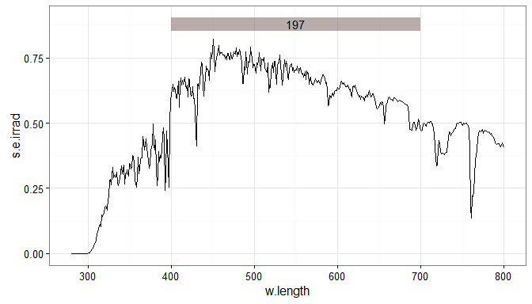

```r
ggplot(sun.spct) +
  stat_wb_total(w.band = PAR(), geom = "rect", alpha = 0.5) +
  stat_wb_total(w.band = PAR(), geom = "text") +
  geom_line() +
  scale_color_identity() +
  scale_fill_identity() +
  theme_bw()
```

If a numeric vector or a spectrum is supplied as argument to `waveband`, its range is calculated and used to construct a temporary `waveband` object.

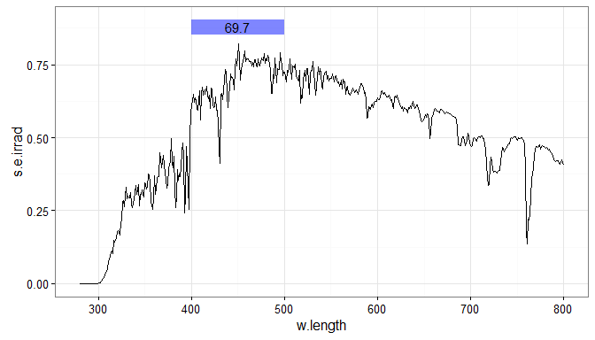

```r
ggplot(sun.spct) +
  stat_wb_total(w.band = c(400,500), geom = "rect", alpha = 0.5) +
  stat_wb_total(w.band = c(400,500), geom = "text") +
  geom_line() +
  scale_color_identity() +
  scale_fill_identity() +
  theme_bw()
```

Lists of wavebands, either user-defined or as in this case using constructor defined in package `photobiologyWavebands` can be also used.

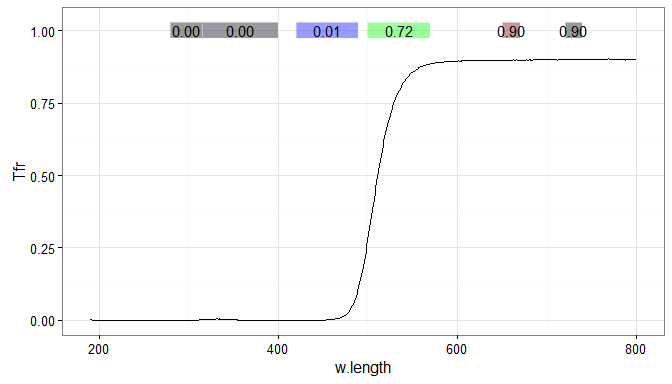

```r
ggplot(yellow_gel.spct) +
  stat_wb_total(w.band = Plant_bands(), geom = "rect", alpha = 0.4, color = "white",
                ypos.fixed = 1) +
  stat_wb_mean(w.band = Plant_bands(), geom = "text", label.fmt = "%1.2f",
               ypos.fixed = 1) +
  geom_line() +
  scale_fill_identity() +
  theme_bw()
```

### Irradiances by waveband

The _stat_s in previous sections can be used for unweighted irradiances, but not for BSWFs. These `irrad` _stat_s have additional formal parameters for passing metadata, and use method `photobiology::irrad()` internaly on a `photobiology::source_spct` object constructed from the data for $x$ and $y$ *aesthetics*. Function `stat_wb_sirrad()` is equivalent to `stat_wb_mean()` and function `stat_wb_irrad()` is equivalent to `stat_wb_total()` following the same convention naming as in package `photobiology`.

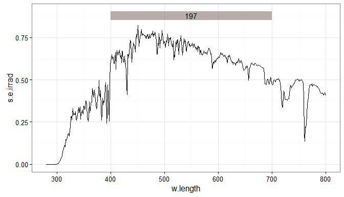

```r
ggplot(sun.spct) +
  stat_wb_irrad(w.band = PAR(), geom = "rect", alpha = 0.5,
                unit.in = "energy", time.unit = "second") +
  stat_wb_irrad(w.band = PAR(), geom = "text",
                unit.in = "energy", time.unit = "second") +
  geom_line() +
  scale_color_identity() +
  scale_fill_identity() +
  theme_bw()
```

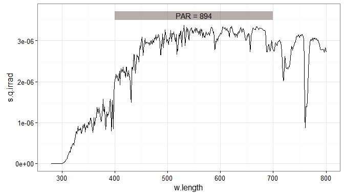

```r
ggplot(sun.spct, unit.out = "photon") +
  stat_wb_irrad(w.band = PAR(), geom = "rect", alpha = 0.5,
                unit.in = "photon", time.unit = "second") +
  stat_wb_irrad(w.band = PAR(), geom = "text",
                unit.in = "photon", time.unit = "second",
                aes(label = sprintf("%s = %.3g", ..wb.name.., ..yint.. * 1e6))) +
  geom_line() +
  scale_color_identity() +
  scale_fill_identity() +
  theme_bw()
```

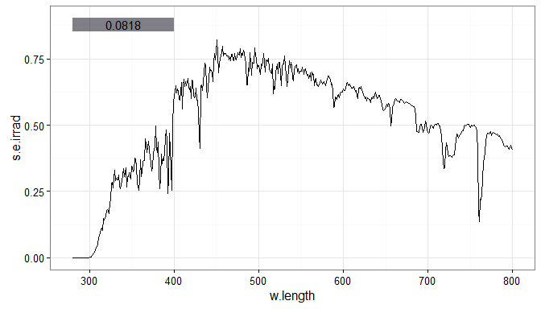

```r
ggplot(sun.spct) +
  stat_wb_irrad(w.band = CIE(), geom = "rect", alpha = 0.5,
                unit.in = "energy", time.unit = "second") +
  stat_wb_irrad(w.band = CIE(), geom = "text",
                unit.in = "energy", time.unit = "second") +
  geom_line() +
  scale_color_identity() +
  scale_fill_identity() +
  theme_bw()
```

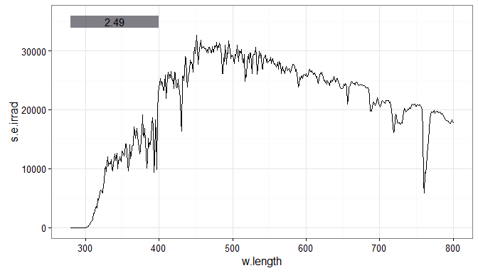

```r
ggplot(sun.daily.spct) +
  stat_wb_irrad(w.band = CIE(), geom = "rect", alpha = 0.5,
                unit.in = "energy", time.unit = "day") +
  stat_wb_irrad(w.band = CIE(), geom = "text",
                unit.in = "energy", time.unit = "day", label.mult = 1e-3) +
  geom_line() +
  scale_color_identity() +
  scale_fill_identity() +
  theme_bw()
```

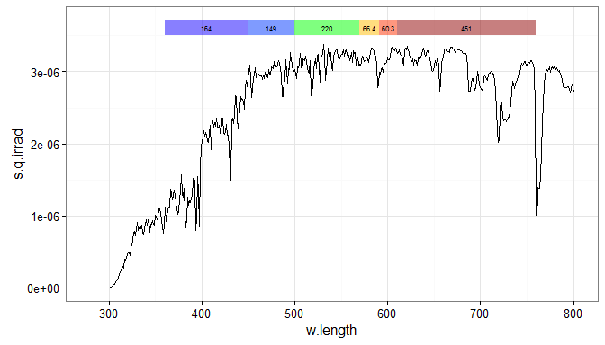

```r
ggplot(sun.spct, unit.out = "photon") +
  stat_wb_irrad(w.band = VIS_bands(), geom = "rect", alpha = 0.5,
                unit.in = "photon", time.unit = "second") +
  stat_wb_irrad(w.band = VIS_bands(), geom = "text",
                unit.in = "photon", time.unit = "second",
                label.mult = 1e6, size = rel(2)) +
  geom_line() +
  scale_color_identity() +
  scale_fill_identity() +
  theme_bw()
```

### Spectral irradiances by waveband

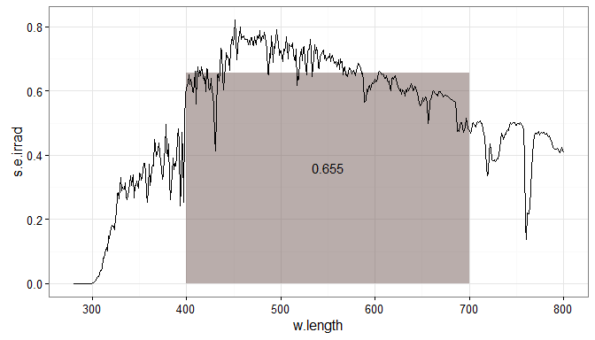

```r
ggplot(sun.spct) +
  stat_wb_sirrad(w.band = PAR(), geom = "rect", alpha = 0.5,
                unit.in = "energy", time.unit = "second") +
  stat_wb_sirrad(w.band = PAR(), geom = "text",
                unit.in = "energy", time.unit = "second") +
  geom_line() +
  scale_color_identity() +
  scale_fill_identity() +
  theme_bw()
```

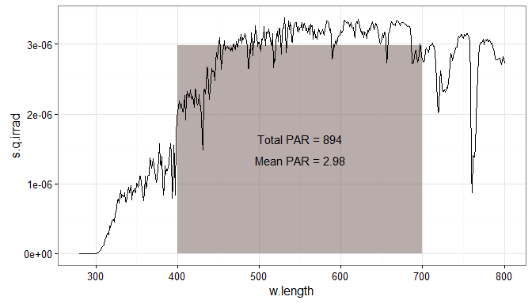

```r
ggplot(sun.spct, unit.out = "photon") +
  stat_wb_sirrad(w.band = PAR(), geom = "rect", alpha = 0.5,
                unit.in = "photon", time.unit = "second") +
  stat_wb_sirrad(w.band = PAR(), geom = "text",
                unit.in = "photon", time.unit = "second",
                aes(label = sprintf("Total %s = %.3g", ..wb.name.., ..yint.. * 1e6))) +
  stat_wb_sirrad(w.band = PAR(), geom = "text",
                unit.in = "photon", time.unit = "second",
                mapping = aes(label = sprintf("Mean %s = %.3g", ..wb.name.., ..ymean.. * 1e6)),
                ypos.mult = 0.45) +
  geom_line() +
  scale_color_identity() +
  scale_fill_identity() +
  theme_bw()
```

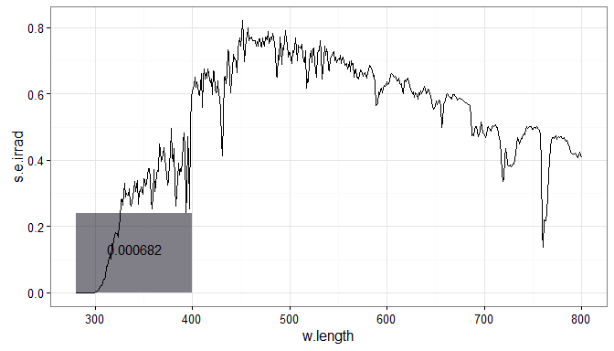

```r
ggplot(sun.spct) +
  stat_wb_sirrad(w.band = CIE(), geom = "rect", alpha = 0.5,
                unit.in = "energy", time.unit = "second") +
  stat_wb_sirrad(w.band = CIE(), geom = "text",
                unit.in = "energy", time.unit = "second") +
  geom_line() +
  scale_color_identity() +
  scale_fill_identity() +
  theme_bw()
```

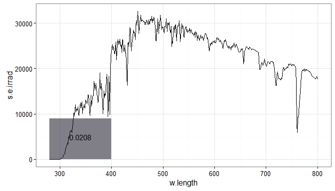

```r
ggplot(sun.daily.spct) +
  stat_wb_sirrad(w.band = CIE(), geom = "rect", alpha = 0.5,
                unit.in = "energy", time.unit = "day") +
  stat_wb_sirrad(w.band = CIE(), geom = "text",
                unit.in = "energy", time.unit = "day", label.mult = 1e-3) +
  geom_line() +
  scale_color_identity() +
  scale_fill_identity() +
  theme_bw()
```

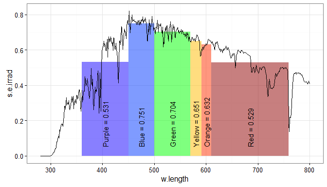

```r
ggplot(sun.spct) +
  stat_wb_sirrad(w.band = VIS_bands(), geom = "rect", alpha = 0.5,
                unit.in = "energy", time.unit = "second") +
  stat_wb_sirrad(w.band = VIS_bands(), angle = 90, geom = "text",
                unit.in = "energy", time.unit = "second", ypos.fixed = 0.05, hjust = 0,
                 aes(label = paste(..wb.name.., ..y.label.., sep = " = "),
                     color = "black")) +
  geom_line() +
  scale_color_identity() +
  scale_fill_identity() +
  theme_bw()
```

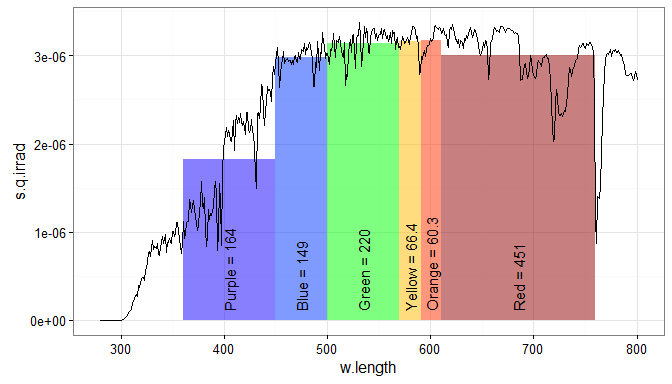

```r
ggplot(sun.spct, unit.out = "photon") +
  stat_wb_sirrad(w.band = VIS_bands(), geom = "rect", alpha = 0.5,
                unit.in = "photon", time.unit = "second") +
  stat_wb_irrad(w.band = VIS_bands(), angle = 90, geom = "text", label.mult = 1e6,
                unit.in = "photon", time.unit = "second", ypos.fixed = 1e-7, hjust = 0,
                 aes(label = paste(..wb.name.., ..y.label.., sep = " = "),
                     color = "black")) +
  geom_line() +
  scale_color_identity() +
  scale_fill_identity() +
  theme_bw()
```

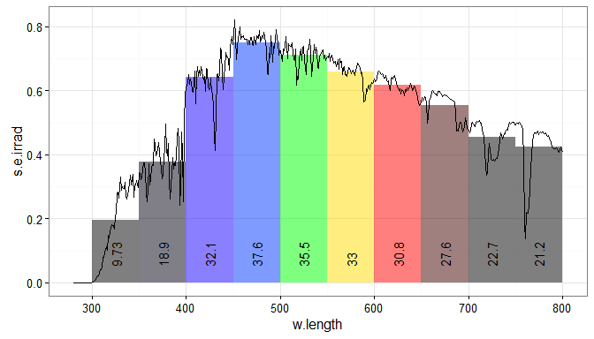

```r
my.bands <- split_bands(c(300,800), length.out = 10)
ggplot(sun.spct) +
  stat_wb_sirrad(w.band = my.bands, geom = "rect", alpha = 0.5,
                unit.in = "energy", time.unit = "second") +
  stat_wb_irrad(w.band = my.bands, angle = 90, geom = "text",
                unit.in = "energy", time.unit = "second", ypos.fixed = 0.05, hjust = 0,
                color = "black") +
  geom_line() +
  scale_color_identity() +
  scale_fill_identity() +
  theme_bw()
```

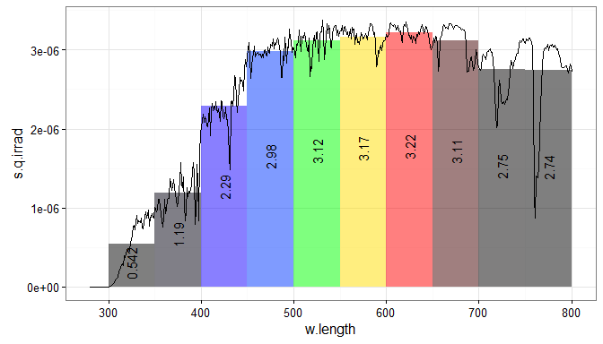

```r
my.bands <- split_bands(c(300,800), length.out = 10)
ggplot(sun.spct, unit.out = "photon") +
  stat_wb_sirrad(w.band = my.bands, geom = "rect", alpha = 0.5,
                unit.in = "photon", time.unit = "second") +
  stat_wb_sirrad(w.band = my.bands, geom = "text", angle = 90,
                unit.in = "photon", time.unit = "second", label.mult = 1e6,
                color = "black") +
  geom_line() +
  scale_color_identity() +
  scale_fill_identity() +
  theme_bw()
```

## Wavelength colours at new $x$-values

The `stat_wl_summary()` and `stat_wb_mean()` return a *reduced* data set with fewer rows than the original data. `stat_wl_strip()` depending on the input, can also return a data set with more rows than the input data. This is the default behaviour, with `w.band` with argument `NULL`. This *stat* operates only on the variable mapped to the $x$ *aesthetic*, a $y$-mapping is not required as input.

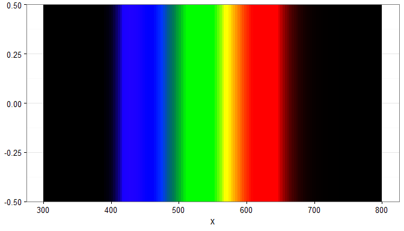

```r
my.data <- data.frame(x = 300:800)
ggplot(my.data, aes(x)) + stat_wl_strip(ymin = -1, ymax = 1) +
    scale_fill_identity()
```

The default *geom* is `"rect"` which with suitable mappings of `ymin` and `ymax` *aesthetics* can be used to add a colour guide to the $x$-axis (if its scale maps wavelengths in nanometres). When `w.band` is `NULL` a long series of contiguous wavebands is generated to create the illusion of a continuous colour gradient.

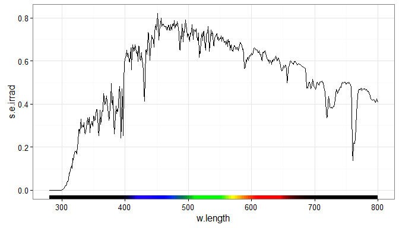

```r
ggplot(sun.spct) +
  geom_line() +
  stat_wl_strip(ymin = -Inf, ymax = -0.025) +
  scale_fill_identity() +
  theme_bw()
```

When a list of wavebands is supplied, it is used for the calculation of colours. These calculations do not use the spectral irradiance, they simply assume a flat spectrum, so the represent the colours of the wavelengths, rather than the colour of the light described by the spectral irradiance.

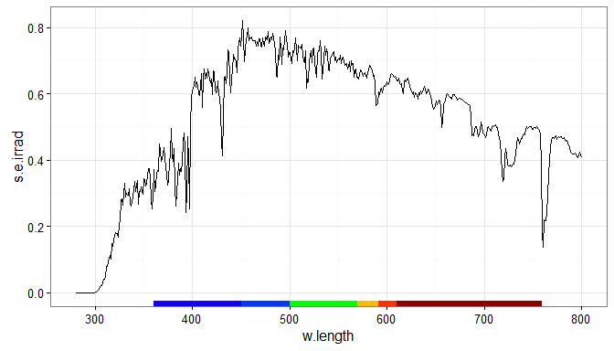

```r
ggplot(sun.spct) +
  geom_line() +
  stat_wl_strip(w.band = VIS_bands(), ymin = -Inf, ymax = -0.025) +
  scale_fill_identity() +
  theme_bw()
```

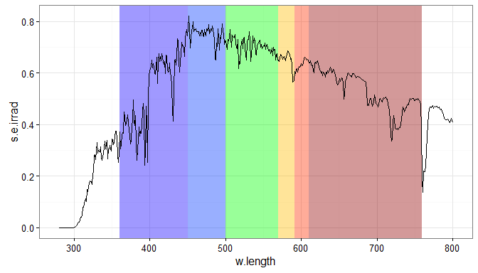

```r
ggplot(sun.spct) +
  stat_wl_strip(w.band = VIS_bands(), ymin = -Inf, ymax = Inf, alpha = 0.4) +
  scale_fill_identity() +
  geom_line() +
  theme_bw()
```

By default an almost continuous colour gradient can be generated for the background.

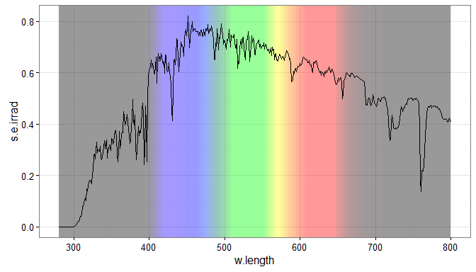

```r
ggplot(sun.spct) +
  stat_wl_strip(alpha = 0.4, ymin = -Inf, ymax = Inf) +
  scale_fill_identity() +
  geom_line() +
  theme_bw()
```

## Multiple stats in the same plot

The *stats* described above can be used together to produce more complex plots. This is just one possibility out of a vast range. Be aware that when adding many layers to the same plot, the order of the layers and adjusting their transparency using the `alpha` *aesthetic* is very important, and best tuned by trial and error.

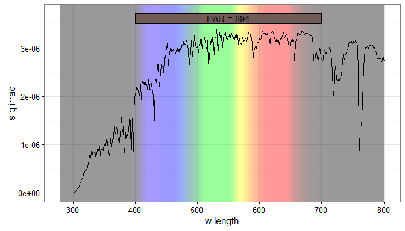

```r
ggplot(sun.spct, unit.out = "photon") +
  stat_wl_strip(alpha = 0.4, ymin = -Inf, ymax = Inf) +
  stat_wb_total(w.band = PAR(), color = "black", geom = "rect") +
  stat_wb_total(w.band = PAR(), label.mult = 1e6,
                geom = "text", color = "black",
                aes(label = paste(..wb.name.., " = ", ..y.label.., sep = ""))) +
  geom_line() +
  scale_fill_identity() +
  theme_bw()
```

## Geometries

A simple *geom* called `"spct"` is defined. It differs from *geom* `"area"` only in the default `position` which is `"stacked"` for *geom* `"area"` and `"identity"` for *geom* `"spct"` which is usually better for spectra.

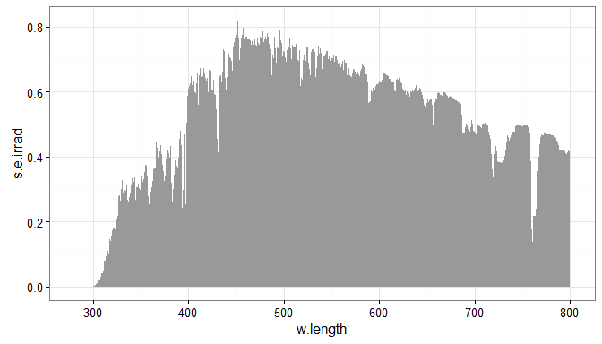

```r
ggplot(sun.spct) + geom_spct()
```

Using as fill the *color* calculated from the spectral data is different to earlier examples in that the spectral irradiance is actually taken into account in the calculation of the colour, instead of just the wavelength range.

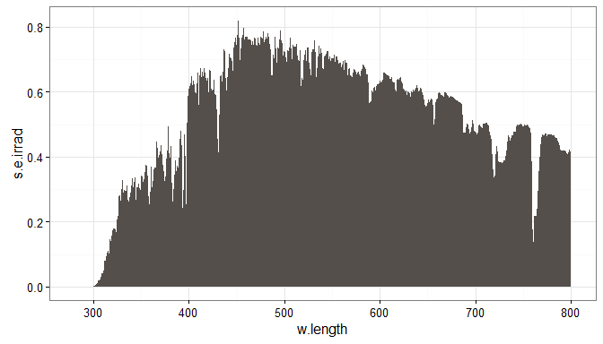

```r
ggplot(sun.spct) +
  geom_spct(fill = color(sun.spct))
```

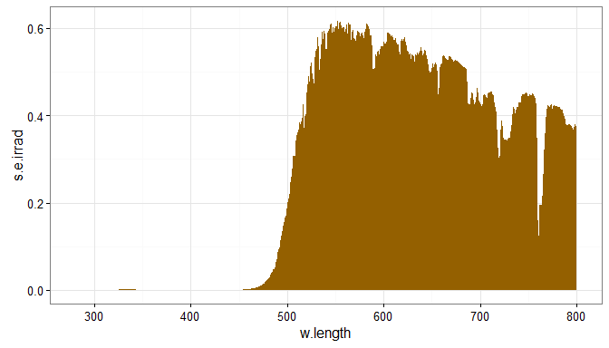

```r
ggplot(sun.spct * yellow_gel.spct) +
  geom_spct(fill = color(sun.spct * yellow_gel.spct))
```

## Packaged stats, geoms plus scales

Some of the examples in previous sections can be simplified by use of `wl_guide()` and `wb_guide()` which add both the statistics and the scale, and provide a default *mapping* for both `ymin` and `ymax`. This is handy for simple plots, but it can generate spurious warnings due to the replacement of existing scales with identical ones. In general only one of `wl_guide()` or `wb_guide()` should be used in a plot, and each one, only once. They just save some typing for the simplest uses, but are not suitable for complex *decorations*.

### wl_guide

The examples for `stat_wl_strip` can be simplified by use of `wl_guide()` which adds both the statistics and the scale, and provides default *mappings* for both `ymin` (`-Inf`) and `ymax` (`Inf`). Another important difference is that the `"rect"` *geom* used cannot be set to a different one by the user.

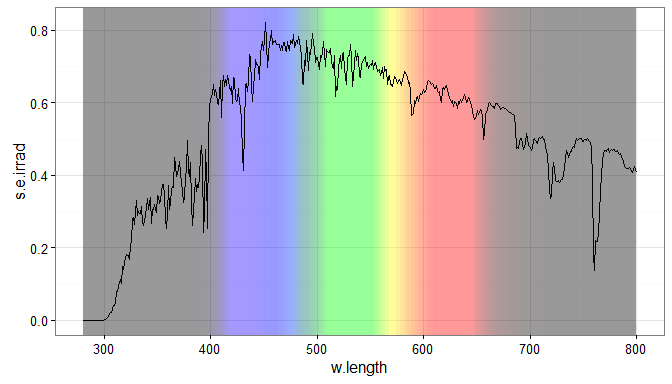

```r
ggplot(sun.spct) +
  wl_guide(alpha = 0.4) +
  geom_line()
```

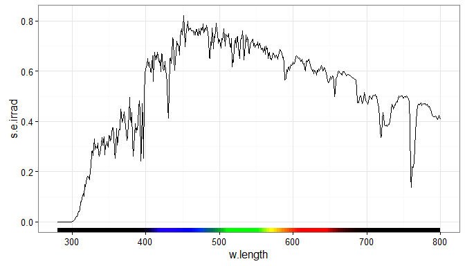

```r
ggplot(sun.spct) +
  wl_guide(ymax = -0.025) +
  geom_line()
```

This example produces a plot with a very different look than earlier ones, but can also be achieved with a very succinct statement.

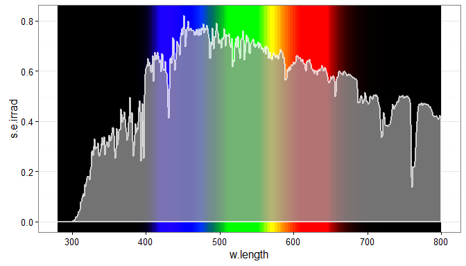

```r
ggplot(sun.spct) +
  wl_guide() +
  geom_spct(alpha = 0.75, colour = "white", size = 1)
```

In the next example we demonstrate a trick achieved by overploting two line of different width (`size`) to make the spectrum visible on a background of variable luminosity.

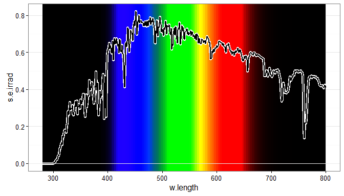

```r
ggplot(sun.spct) +
  wl_guide() +
  geom_line(size = 2, colour = "white") +
  geom_line(size = 1, colour = "black") +
  geom_hline(yintercept = 0, colour = "grey92") +
  theme_bw()
```

## Plotting spectra

The most automatic way of plotting spectral data stored in one of the classes defined in package `photobiology` is to use the `plot()`methods. These go much further than the `plot()` method defined in base-R for numeric data, as these classes store metadata that allows the automatic construction of axis labels as quantities and units are well defined.

Here we use the same example `source_spct` object from package `photobiology` used earlier in the User Guide. In contrast to earlier examples, here we obtain with a very simple statement a very complete and properly annotated plot of the solar spectrum at ground level.

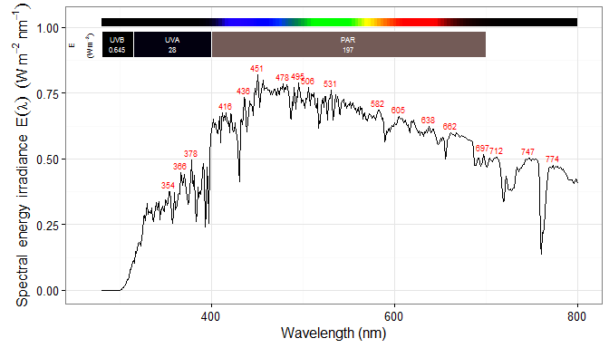

```r
plot(sun.spct)
```

Although the defaults provide a useful plot, the `plot()` method accepts arguments for several parameters that allow to tweak the looks and contents of the plots significantly, without having to do any explicit manipulation of the spectral data.

This first example, shows means instead of integrals in the labels. Note that the units and quantity labels for the waveband summaries have also changed automatically.

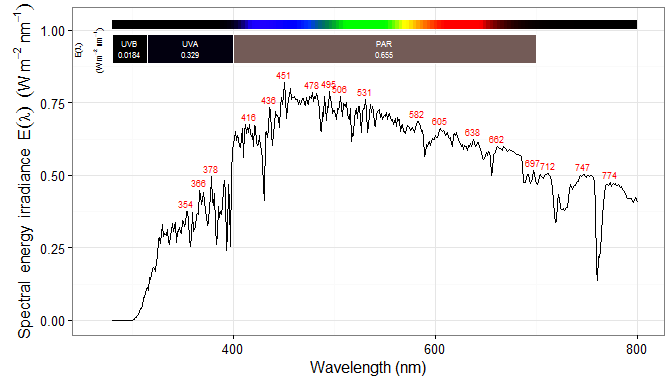

```r
plot(sun.spct, label.qty = "mean")
```

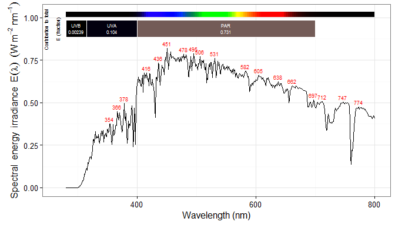

```r
plot(sun.spct, label.qty = "contribution")
```

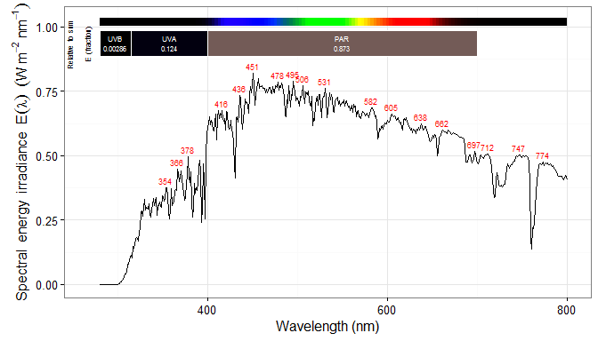

```r
plot(sun.spct, label.qty = "relative")
```

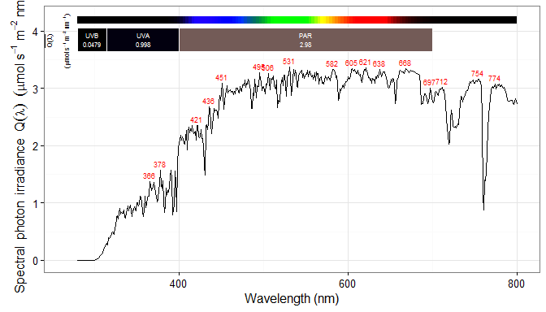

```r
plot(sun.spct, label.qty = "mean", unit.out = "photon")
```

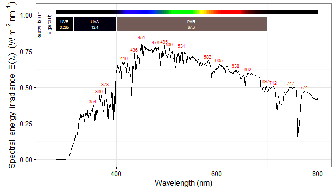

```r
plot(sun.spct, label.qty = "relative.pc")
```

We can change the basis of expression of spectral irradiance and irradiance from `"energy"` to `"photon"`. Be aware that by design, all values, summaries and spectral data will always use the same base of expression.

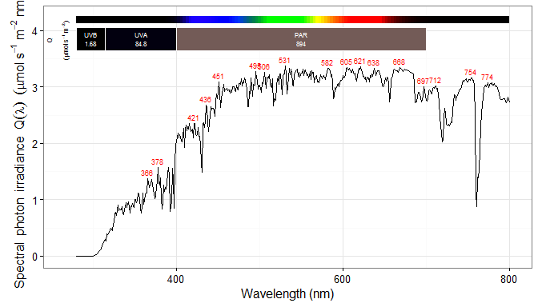

```r
plot(sun.spct, unit.out = "photon")
```

Which *annotations* are included can be also controlled through parameter `annotations`.

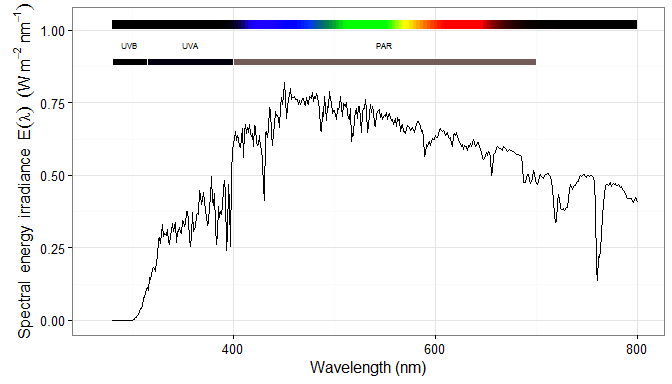

```r
plot(sun.spct, annotations = c("segments", "labels", "color.guide"))
```

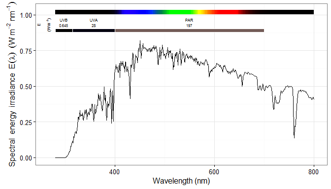

```r
plot(sun.spct,
     annotations = c("segments", "labels", "summaries", "color.guide"))
```

Arguments `range` and `w.band` play very different roles. The first one determines the `range` of wavelengths to include in the data plotted, which is slightly different to the effect of `ggplot2::xlim()` as `range` is used to *trim* (see `photobiology::trim_wl()`) the spectral data **before** passing it to `ggplot`. The second one, `w.band` is only used for the *annotations* and decorations. It should be however noted, that a `waveband` object is a valid argument for both `range` and `w.band`.

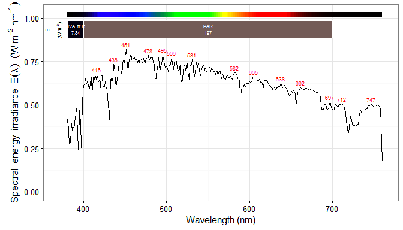

```r
plot(sun.spct, range = VIS())
```

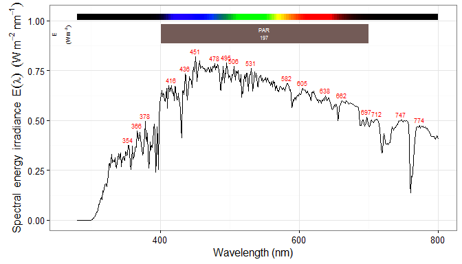

```r
plot(sun.spct, w.band = PAR())
```

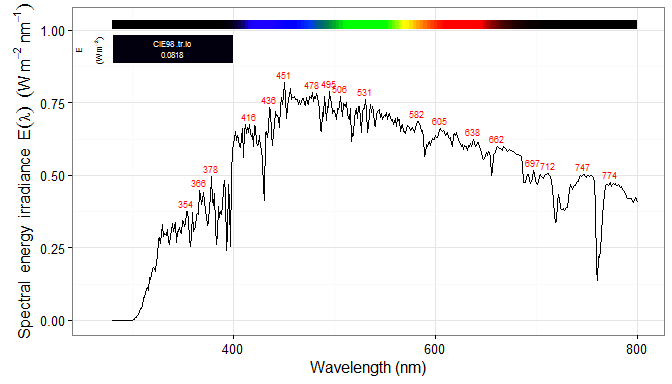

```r
plot(sun.spct, w.band = CIE())
```

The time unit is also stored in the metadata, as demonstrated here. The units in axis labels have suitably adapted to the different units.

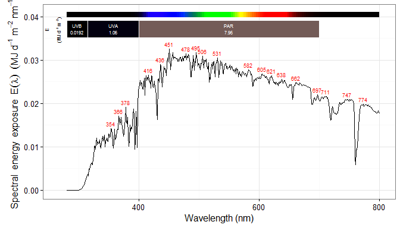

```r
plot(sun.daily.spct)
```

Even though the `plot()` methods can return a finished plot, the returned object is a `ggplot` object and can be built upon by adding additional elements like *facets*, *aesthetics* and even additional *layers*.

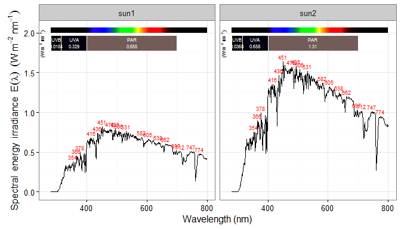

```r
plot(two_suns.spct, label.qty = "mean") + facet_wrap(~spct.idx)
```

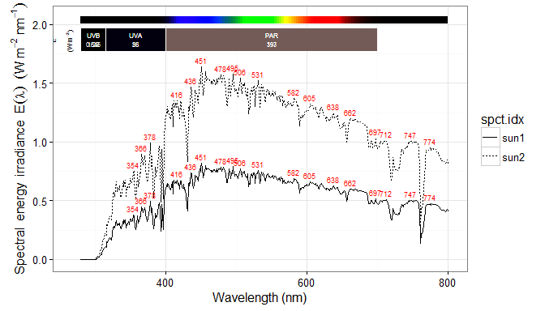

```r
plot(two_suns.spct) + aes(linetype = spct.idx)
```

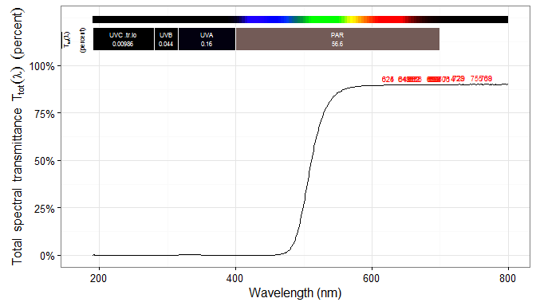

```r
plot(yellow_gel.spct, pc.out = TRUE)
```

Here we demonstrate something that may look like a bug, but is not. The annotations are based only on the data supplied as argument to `plot()` (or in other cases `ggplot()`) because these are the only data visible in all *layers*. The `data` argument in `geom_spct()` only affects the data seen by this *geom*. This way of building a plot is very different than when using *grouping* within a single data set, and it is best to avoid it in most situations.

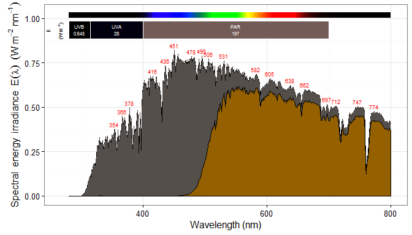

```r
plot(sun.spct) + geom_spct(fill = color(sun.spct)) +
  geom_spct(data = yellow_gel.spct * sun.spct, color = "black",
            fill = color(yellow_gel.spct * sun.spct))
```

However, if one really needs to, one can add a suitable *stat* using ‘local’ data. As this is just a demonstration, I will avoid adding all the additional arguments needed to make the annotations of peaks match those produced by `plot()`.

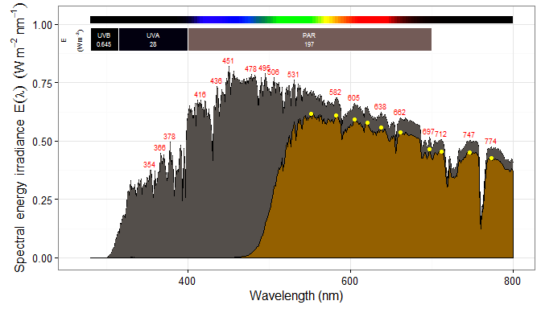

```r
plot(sun.spct) + geom_spct(fill = color(sun.spct)) +
  geom_spct(data = yellow_gel.spct * sun.spct, color = "black",
            fill = color(yellow_gel.spct * sun.spct)) +
  stat_peaks(data = yellow_gel.spct * sun.spct, color = "yellow",
             ignore_threshold = 0.1, span = 21)
```

As with any `ggplot` object, the ‘looks’ of the returned object depends on both the local and global `ggplot` *theme*.

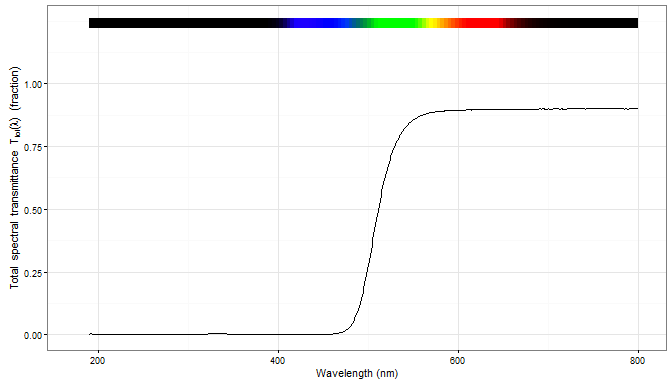

```r
theme_set(theme_bw(8))
plot(yellow_gel.spct, annotations = "colour.guide")
```